# Correspondence Analysis

Dataset df_contingency

This dataset contains 165 rows and 24 columns.

### 1. Study of the outliers

The detection of outliers does not apply to CA results.

### 2. Inertia distribution

The inertia of the first dimensions shows if there are strong relationships between variables and suggests the number of dimensions that should be studied.

The first two dimensions of analyse express **28.44%** of the total dataset inertia ; that means that 28.44% of the rows (or columns) cloud total variability is explained by the plane. This is a small percentage and the first plane just represents a part of the data variability. This value is greater than the reference value that equals **15.74%**, the variability explained by this plane is thus significant (the reference value is the 0.95-quantile of the inertia percentages distribution obtained by simulating 873 data tables of equivalent size on the basis of a uniform distribution).

From these observations, it is interesting to consider the next dimensions which also express a high percentage of the total inertia.

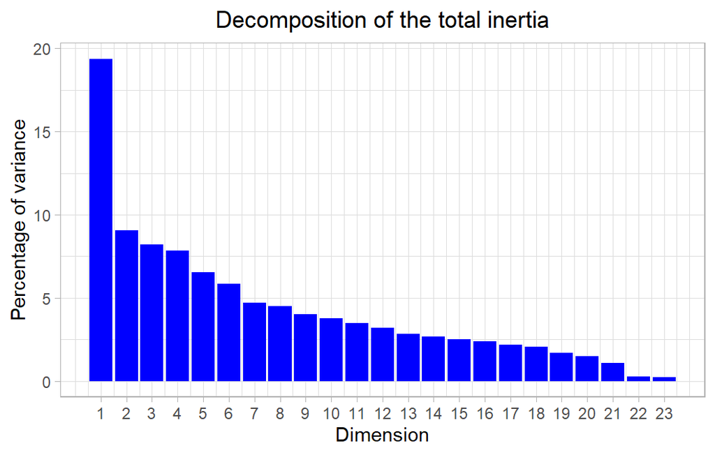

**Figure 2 - Decomposition of the total inertia**

An estimation of the right number of axis to interpret suggests to restrict the analysis to the description of the first 6 axis. These axis present an amount of inertia greater than those obtained by the 0.95-quantile of random distributions (56.85% against 40.67%). This observation suggests that only these axis are carrying a real information. As a consequence, the description will stand to these axis.

### 3. Description of the plane 1:2

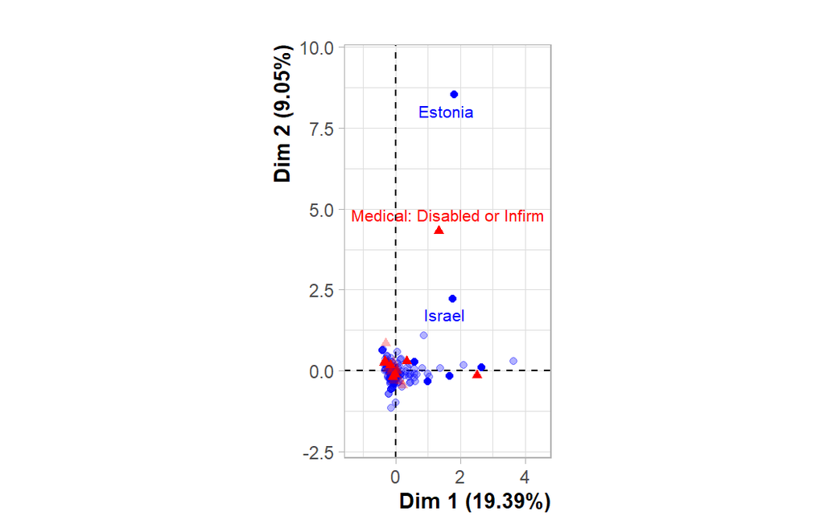

**Figure 3.1 - Overlayed factor map (CA)** *The labeled rows are those with the higher contribution to the plane construction.* *The labeled columns are those the best shown on the plane.*

The **dimension 1** opposes factors such as *Bangladesh*, *India* and *Israel* (to the right of the graph, characterized by a strongly positive coordinate on the axis) to factors such as *Somalia*, *Cuba*, *Mexico* and *Haiti* (to the left of the graph, characterized by a strongly negative coordinate on the axis).

The group in which the factors *Bangladesh*, *India* and *Israel* stand (characterized by a positive coordinate on the axis) is sharing :

- factors whose frequency does not differ significantly from the mean.

The group in which the factors *Somalia*, *Cuba*, *Mexico* and *Haiti* stand (characterized by a negative coordinate on the axis) is sharing :

- factors whose frequency does not differ significantly from the mean.

Note that the factors *India*, *Bangladesh* and *Hunger Strike* are highly correlated with the dimension (respective correlation of 0.92, 0.93, 0.97). These factors could therefore summarize themselve the dimension 1.

The group in which the factor *Estonia* stands (characterized by a positive coordinate on the axis) is sharing :

- factors whose frequency does not differ significantly from the mean.

The group in which the factors *Somalia*, *Cuba*, *Mexico* and *Haiti* stand (characterized by a negative coordinate on the axis) is sharing :

- factors whose frequency does not differ significantly from the mean.

### 4. Description of the plane 3:4

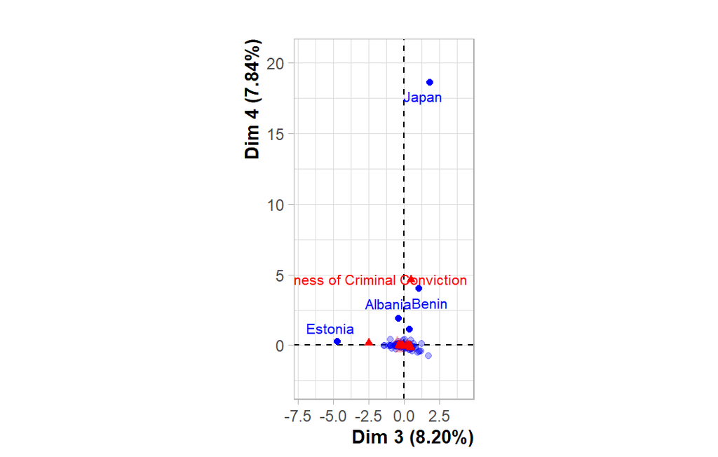

**Figure 4.1 - Overlayed factor map (CA)** *The labeled rows are those with the higher contribution to the plane construction.* *The labeled columns are those the best shown on the plane.*

The **dimension 3** opposes factors such as *Japan* and *Turkey* (to the right of the graph, characterized by a strongly positive coordinate on the axis) to factors such as *Jamaica*, *Estonia*, *Haiti* and *Mexico* (to the left of the graph, characterized by a strongly negative coordinate on the axis).

The group in which the factor *Turkey* stands (characterized by a positive coordinate on the axis) is sharing :

- factors whose frequency does not differ significantly from the mean.

The group in which the factor *Japan* stands (characterized by a positive coordinate on the axis) is sharing :

- factors whose frequency does not differ significantly from the mean.

The group in which the factor *Estonia* stands (characterized by a negative coordinate on the axis) is sharing :

- high frequency for the variable *Medical:.Disabled.or.Infirm*.

The group in which the factors *Jamaica*, *Haiti* and *Mexico* stand (characterized by a negative coordinate on the axis) is sharing :

- factors whose frequency does not differ significantly from the mean.

The **dimension 4** opposes factors such as *Japan*, *Benin* and *Albania* (to the top of the graph, characterized by a strongly positive coordinate on the axis) to factors such as *Jamaica*, *Haiti* and *Mexico* (to the bottom of the graph, characterized by a strongly negative coordinate on the axis).

The group in which the factors *Benin* and *Albania* stand (characterized by a positive coordinate on the axis) is sharing :

- factors whose frequency does not differ significantly from the mean.

The group in which the factor *Japan* stands (characterized by a positive coordinate on the axis) is sharing :

- factors whose frequency does not differ significantly from the mean.

The group in which the factors *Jamaica*, *Haiti* and *Mexico* stand (characterized by a negative coordinate on the axis) is sharing :

- factors whose frequency does not differ significantly from the mean.

### 5. Description of the plane 5:6

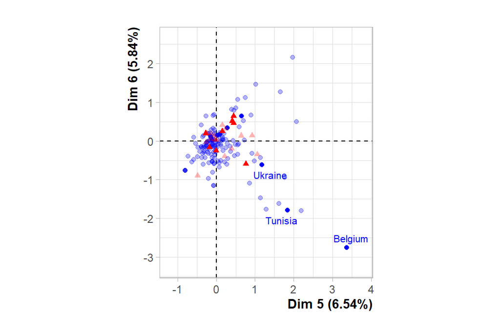

**Figure 5.1 - Overlayed factor map (CA)** *The labeled rows are those with the higher contribution to the plane construction.* *The labeled columns are those the best shown on the plane.*

The **dimension 5** opposes factors such as *Belgium*, *Tunisia*, *Ukraine*, *Ecuador* and *Haiti* (to the right of the graph, characterized by a strongly positive coordinate on the axis) to factors such as *Honduras* and *El Salvador* (to the left of the graph, characterized by a strongly negative coordinate on the axis).

The group in which the factors *Ukraine*, *Ecuador* and *Haiti* stand (characterized by a positive coordinate on the axis) is sharing :

- factors whose frequency does not differ significantly from the mean.

The group in which the factors *Belgium* and *Tunisia* stand (characterized by a positive coordinate on the axis) is sharing :

- factors whose frequency does not differ significantly from the mean.

The group in which the factors *Honduras* and *El Salvador* stand (characterized by a negative coordinate on the axis) is sharing :

- factors whose frequency does not differ significantly from the mean.

- factors whose frequency does not differ significantly from the mean.

The group in which the factors *Belgium* and *Tunisia* stand (characterized by a negative coordinate on the axis) is sharing :

- factors whose frequency does not differ significantly from the mean.